# An Introduction to Tidy R Spatial Packages: Incorporating Historic Sociodemographic Data from the US Census and Visualizing Geographic Distributions

# F. Mapping the Data

Use the `ggplot::geom_sf()` in order to plot the Census tract boundaries for New York.

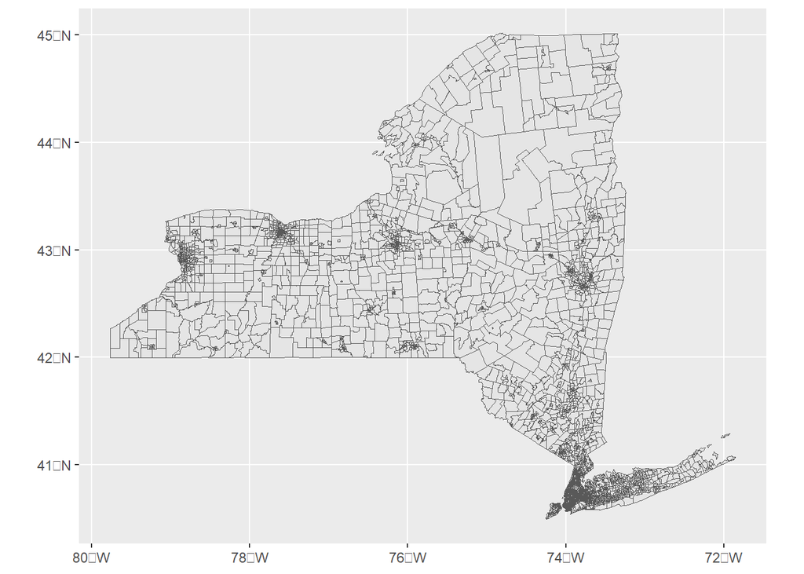

```r
merged %>%
  ggplot() +
  ggplot2::geom_sf()
```

## F.1. Creating a Choropleth Map for a Single Variable

A choropleth map is a thematic map in which areas are shaded or patterned in proportion to the value of a variable being represented. This type of map is commonly used to visualize how a measurement varies across a geographic area, such as population density or median income.

### … Adding in a variable to create choropleth map

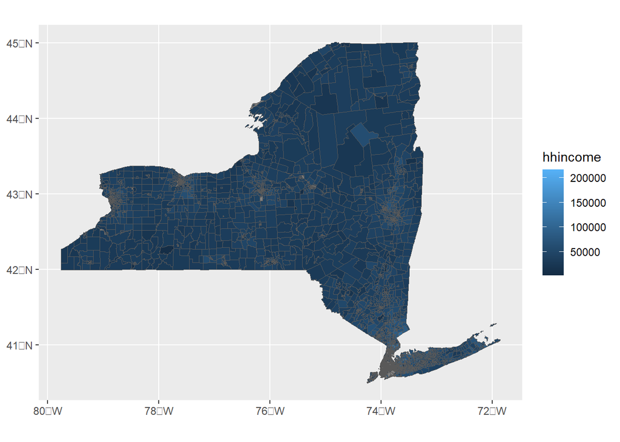

```r
smap_1 <- merged %>%
  ggplot() +
  geom_sf(aes(fill = hhincome))

smap_1
```

### … Change legend colors

Use the `low` and `high` arguments in the `scale_fill_continuous()` to specify colors to use for low and high values on a continuous scale.

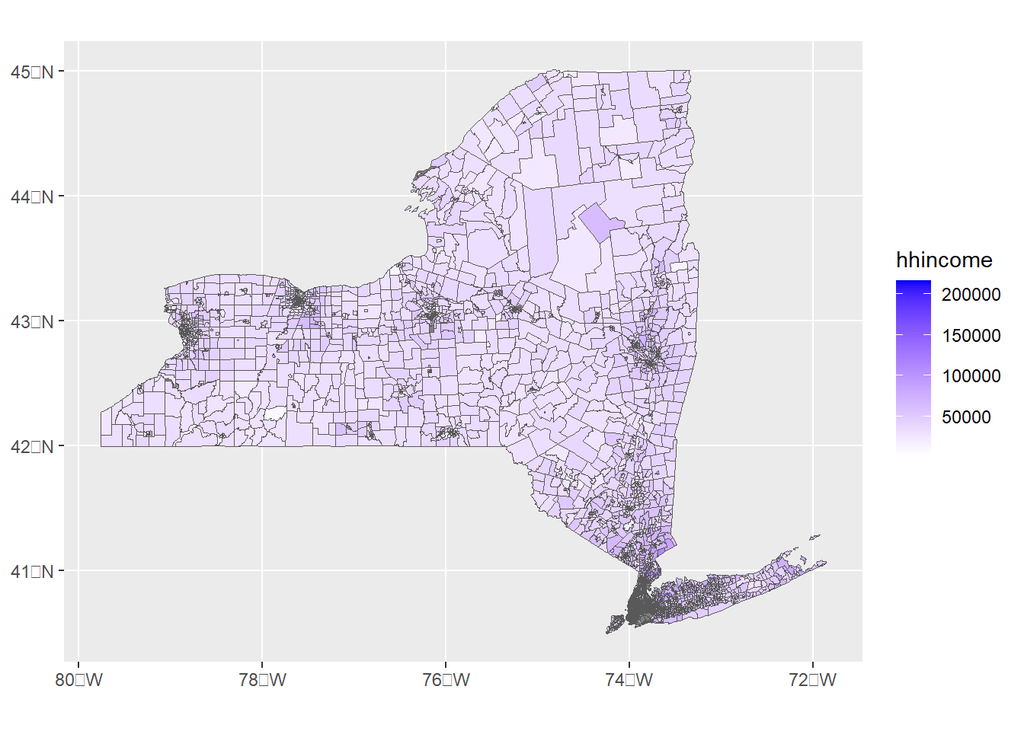

```r
smap_2 <- smap_1 +
  scale_fill_continuous(low = 'white', high = 'blue')

smap_2
```

### … Changing map theme

Use the `theme_void()` function to remove the background and axis marks.

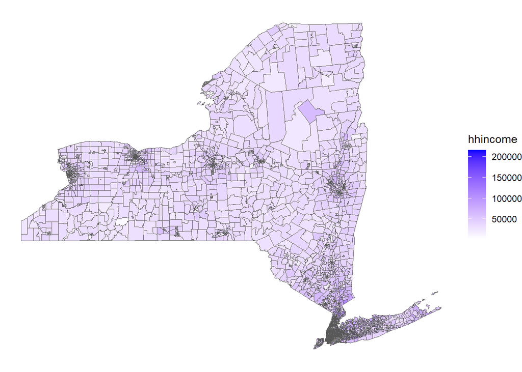

```r
smap_3 <- smap_2 +
  theme_void()

smap_3
```

### … add a title

Use the `title` argument in the `labs()` function in order to create a title for the map.

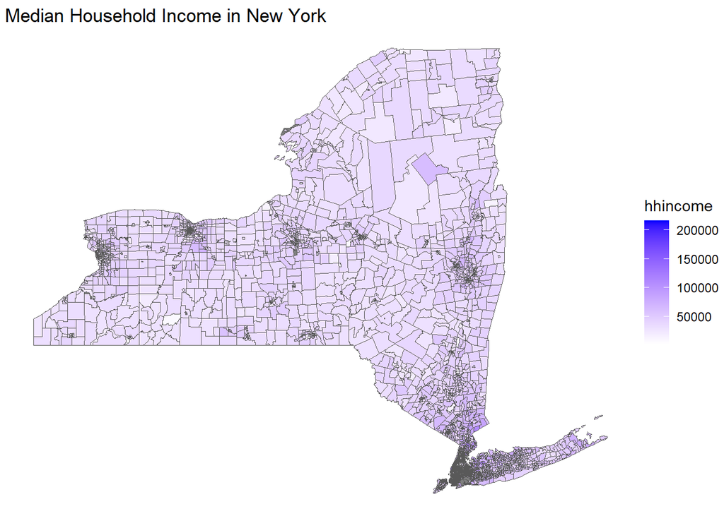

```r
smap_4 <- smap_3 +
  labs(title = 'Median Household Income in New York')

smap_4
```

### … adding in a north arrow and scale bar

Use the `annotation_north_arrow()` and `annotation_scale()` functions from the ggspatial package to add in a north arrow and scalebar to the map - best practices when building a map.

- The `location = tl` argument in `annotation_north_arrow()` function is used to place the north arrow on the top left area of the map.
- The `unit_category = 'imperial'` argument in `annotation_scale()` function is used to change the units in the scale bar from metric to imperial units (showing miles instead of kilometers).

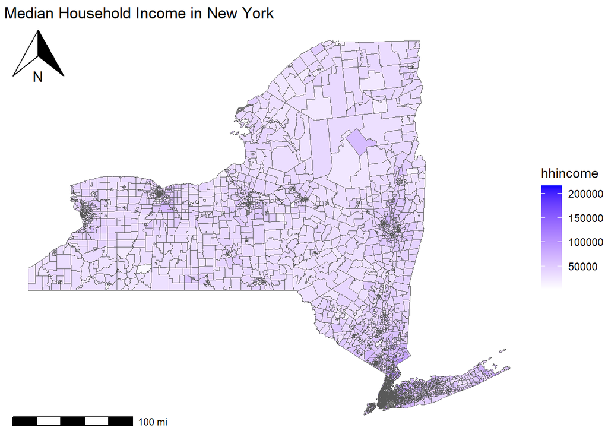

```r
smap_5 <- smap_4 +
  ggspatial::annotation_north_arrow(location = 'tl') + # tl for top-left
  ggspatial::annotation_scale(unit_category = 'imperial') # imperial units to show miles instead of km

smap_5
```

### Putting it all together

We can create the map using the previous functions in one step.

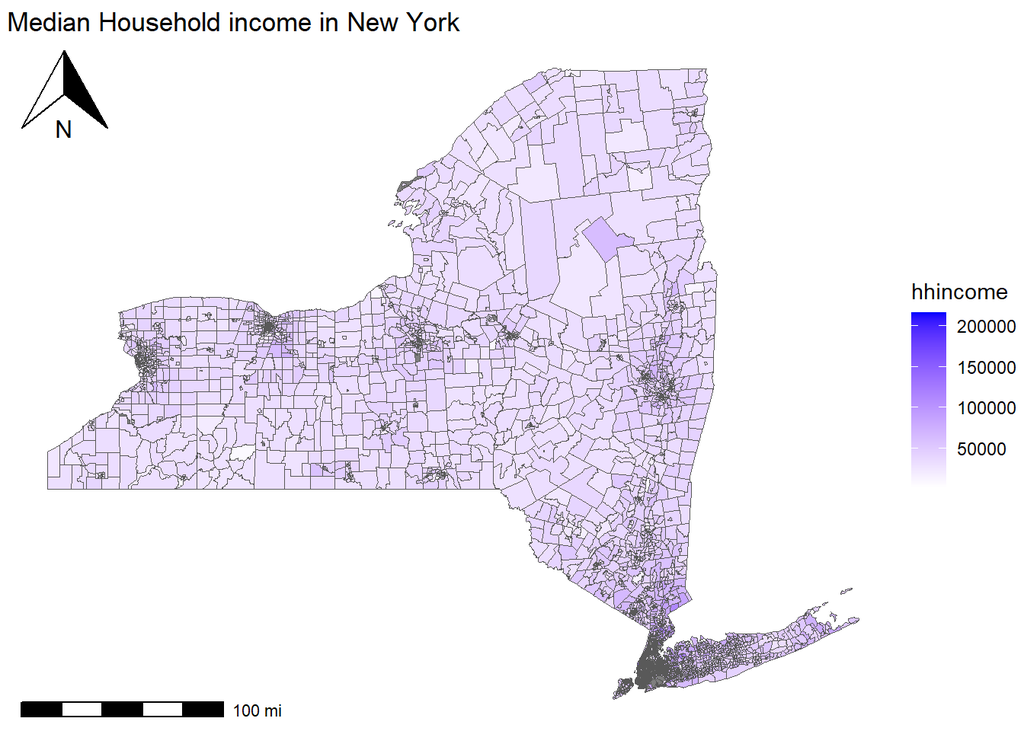

```r
smap <- merged %>%
  ggplot() +
  geom_sf(aes(fill = hhincome)) +
  scale_fill_continuous(low = 'white', high = 'blue') +
  theme_void() +
  labs(title = 'Median Household income in New York') +
  ggspatial::annotation_north_arrow(location = 'tl') +
  ggspatial::annotation_scale(unit_category = 'imperial')

smap
```

## F.2. Creating Choropleth Maps for Multiple Variables

### Prepare long dataset with CHD and educational variables

Long datasets are easier to use with ggplot2.

A long dataset, also known as a “tidy” dataset, is structured so that each row represents a single observation, with one column for each variable and an additional column for the values. This format is often used for time series or repeated measures data.

In contrast, a wide dataset has a format where each row represents a single subject or entity, with multiple columns for different measurements or observations taken at different times or under different conditions. This format is common in datasets where comparisons across different time points or conditions are needed.

We use the `tidyr::pivot_longer()` function in order to create one column for the values of the CHD and educational attainment variables in our dataset.

```r
merged_long <- merged %>%
  tidyr::pivot_longer(cols = c(chd_prev, perc_lessthanhs, perc_hs, perc_somecollege, perc_bachelors),
                      names_to = 'variable_name',
                      values_to = 'value')
```

### Create a Facet Plot

Use the `facet_wrap()` function to create a facet plot (allows us to create multiple maps in a grid) for our 5 variables. We use the `ncol = 3` argument to specify that we would like to create a grid of maps with 3 columns.

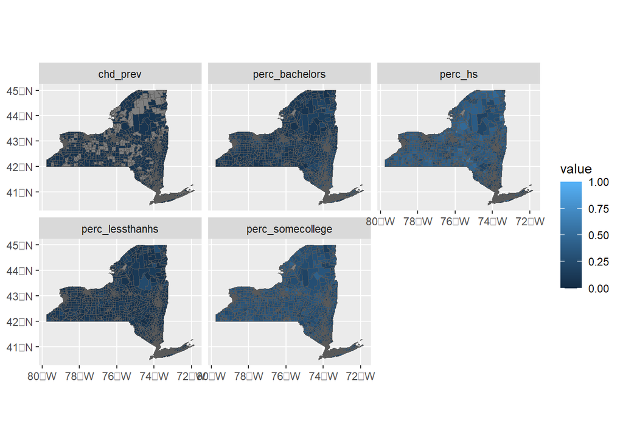

```r
multmap_1 <- merged_long %>%
  ggplot() +
  ggplot2::geom_sf() +
  geom_sf(aes(fill = value)) +
  facet_wrap(vars(variable_name), ncol = 3)
multmap_1
```

### … Adding in different legend colors, theme, title, north arrow, and scalebar

Use the same functions as we used with the single variable choropleth map in order to add different legend colors, theme, a title, a north arrow, and a scalebar. Use the `height` and `width` arguments in the `ggspatial::annotation_north_arrow()` function in order to change the size of the north arrow.

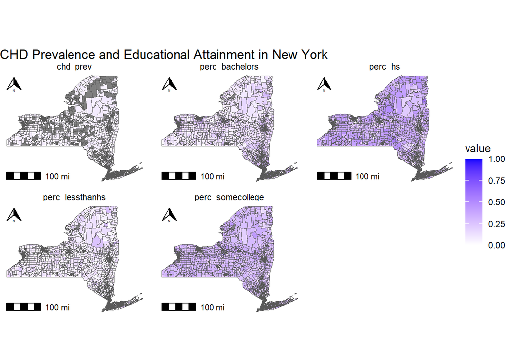

```r
multmap_2 <- multmap_1 +
  scale_fill_continuous(low = 'white', high = 'blue') +
  theme_void() +
  labs(title = 'CHD Prevalence and Educational Attainment in New York') +
  ggspatial::annotation_north_arrow(location = 'tl', height = unit(0.5, "cm"), width = unit(0.5, "cm"),
                                    style = north_arrow_orienteering(text_size = 1)) +
  ggspatial::annotation_scale(unit_category = 'imperial')

multmap_2
```

### Putting it all together

We can create the map using the previous functions in one step.

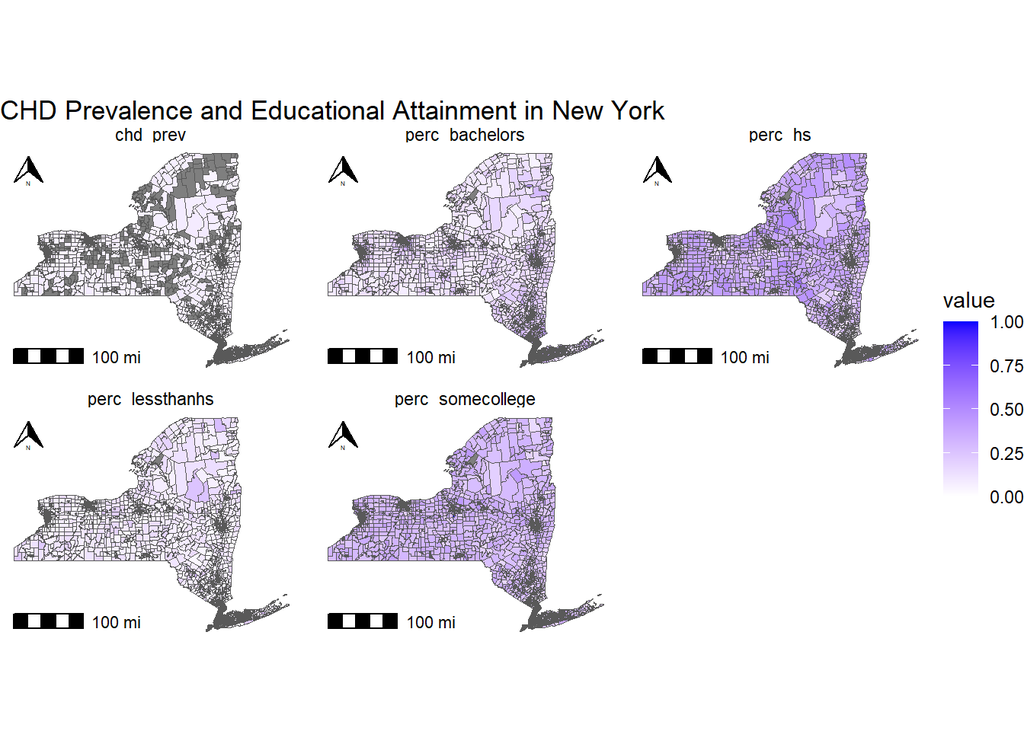

```r
multmap <- merged_long %>%
  ggplot() +
  ggplot2::geom_sf() +
  geom_sf(aes(fill = value)) +
  facet_wrap(vars(variable_name), ncol = 3) +
  scale_fill_continuous(low = 'white', high = 'blue') +
  theme_void() +
  labs(title = 'CHD Prevalence and Educational Attainment in New York') +
  ggspatial::annotation_north_arrow(location = 'tl', height = unit(0.5, "cm"), width = unit(0.5, "cm"),
                                    style = north_arrow_orienteering(text_size = 1)) +
  ggspatial::annotation_scale(unit_category = 'imperial')

multmap
```

## F.3. Combining Multiple Maps

Using the patchwork package, we can use the `/` operator to stack our previously created maps, one on top of the other. The map below is only a quick example. When producing a map to share, you would want to change the north arrow, scalebar, and text sizes.

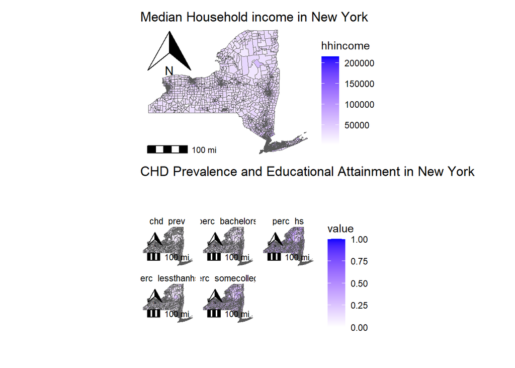

```r
smap / multmap
```

# G. Additional Resources

In case you would like to learn more about geocomputation, data wrangling, or the tidycensus package, here are some additional resources:

- [Geocomputation with R (free online book)](https://r.geocompx.org/)
- [R for Data Science (free online book)](https://r4ds.hadley.nz/)
- [Vignette for the tidycensus package](https://walker-data.com/tidycensus/articles/basic-usage.html)